# A Look at a New York Shooting Database

## Unfortunately there was a lot of missing data - but I was able to gleam a little info that most the shootings over the years were happening within or near public and multidwelling housing. This leaps out at me like it could be a financial, population density and police services that could be affecting this…it would take a bit more reseaerch and statistics to figure that out. But I do want to pursue who is shooting who.

## To do this I had to eliminate some confounding errors that through off the charts and data.

```r
df1 = gunshots_tidy

shoot = df1[!df1$PERP_AGE_GROUP =="(null)",]
shoot = shoot[!shoot$PERP_AGE_GROUP =="1020",]
shoot = shoot[!shoot$PERP_AGE_GROUP =="940",]
shoot = shoot[!shoot$PERP_AGE_GROUP =="UNKNOWN",]
shoot = shoot[!shoot$PERP_AGE_GROUP == "NA",]
shoot = shoot[!shoot$PERP_AGE_GROUP == "224",]
shoot = shoot[!shoot$VIC_AGE_GROUP =="1022",]
shoot = shoot[!shoot$VIC_AGE_GROUP =="UNKNOWN",]
```

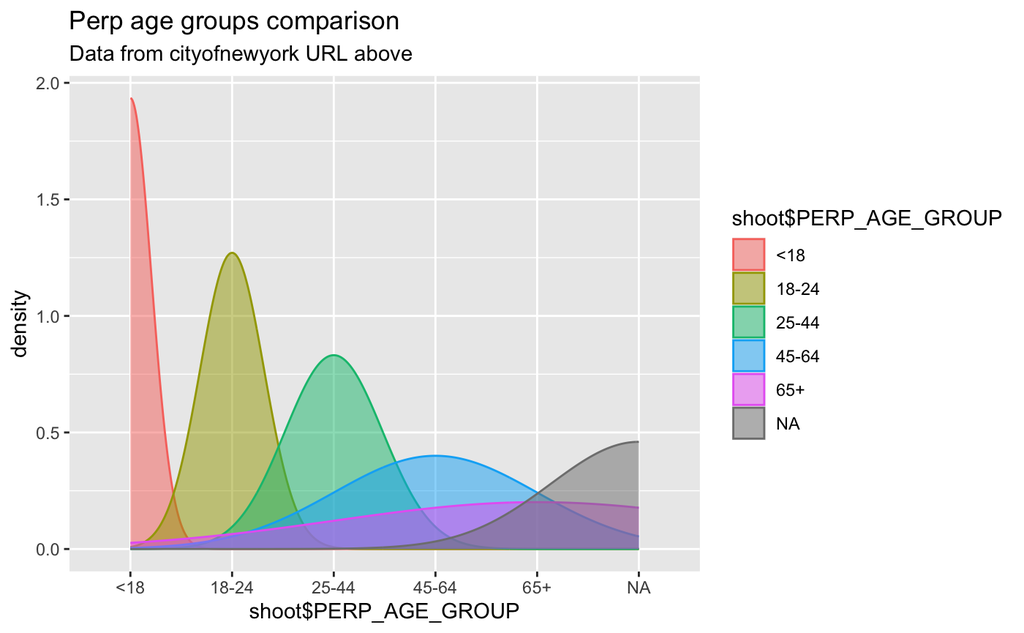

```r
ggplot(shoot, aes(x = shoot$PERP_AGE_GROUP, color = shoot$PERP_AGE_GROUP, fill = shoot$PERP_AGE_GROUP ))+
  geom_density(alpha=.5)+
    labs(
      title = "Perp age groups comparison",
    subtitle="Data from cityofnewyork URL above"
  )
```

### So the above plot did not work out too well it seemed to show that the younger individuals were shooting more but – something is wrong with the calculation in density for under 18 so I decided to return to BAR CHART.

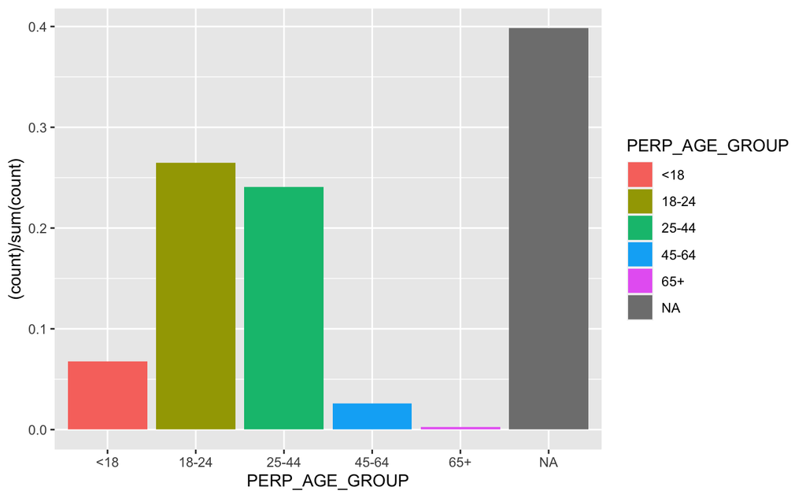

```r
ggplot(shoot, aes(x = PERP_AGE_GROUP)) +
  geom_bar(aes(y = (..count..)/sum(..count..), fill =PERP_AGE_GROUP)
)
```

### This one definetly shows age does appear to have different results. But, I needed more info so I added victims to the perp count and as shown below, sadly, youths were shooting youths more than older adults were shooting anyone. Again really sad info if you think about it.

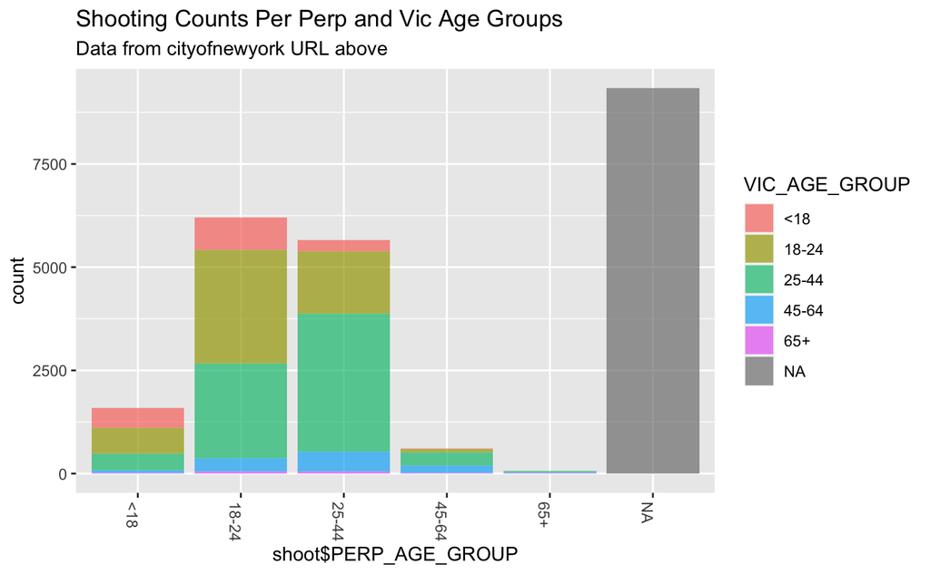

```r
ggplot(shoot,aes(x = shoot$PERP_AGE_GROUP, fill = VIC_AGE_GROUP))+
  geom_bar(alpha = .7)+
  theme(axis.text.x=element_text(angle = -90, hjust = 0)) +
  labs(
    title = "Shooting Counts Per Perp and Vic Age Groups",
    subtitle="Data from cityofnewyork URL above"
  )
```